# 26103期：FM-1.7.1与历史让平率校正追加诊断

本研究固定上一轮GLOBAL候选，不以26103赛果调参，不升级正式FM。原生λ只用目标同赛事、同场地历史，长期与近期各0.5、近期8场，最低12场及ESS8；ρ固定−0.1。共同三路盘口未就绪时不能用欧赔单独冒充联合市场，按现有来源规则保留原生并披露uncertain。原生支持不足及时间冲突逐场留空。其后使用累计严格超过90%的净胜球核心、外围0.3，冻结完整比分，最后映射实际北单线。

本期按实际证据执行来源裁决：旧目录另有末段25场亚洲/大小球原文，经重放只有3场通过固定市场标准，最终是否切换还取决于原生身份/样本准入。其余分支不能用欧赔单独代替完整市场。未经同版估计的旧FM15/16预测不混入。未据希望的Top1、让球线或目标比分返调λ。没有逐场已标定置信分数；可靠性账本由Codex根据可用事实填写，未调用JEV。

本期407场为固定分母。目标名单本身包含已知比分，源历史采集在赛后，本项目也有既往赛果知识；不能声称盲测或严格前瞻样本外验证。当前目标比分仅进入独立评分客户端，不进入原生、来源裁决、尾部或历史校正拟合。下列完成数与排除均来自实际账本。

全407场估计/排除；失败不是零概率

| state | reason | fixtures |
| --- | --- | --- |
| ESTIMATED | Formal same-support native; source market ; fixed FM171 tail | 1 |
| ESTIMATED | Formal same-support native; source native ; fixed FM171 tail | 302 |
| UNESTIMATED | Sparse target competition/venue support | 57 |
| UNESTIMATED | Unresolved roster/analysis/market kickoff disagreement | 47 |

实际来源路由；uncertain不等于胜率低

| state | selected_source | market_sufficient | market_consistent | n |
| --- | --- | --- | --- | --- |
| ESTIMATED | market | TRUE | TRUE | 1 |
| ESTIMATED | native | FALSE | FALSE | 298 |
| ESTIMATED | native | FALSE | TRUE | 4 |
| UNESTIMATED | NA | FALSE | FALSE | 104 |

三个市场合格候选及实际来源；市场支持与原生准入分开

| fixture_id | available | sufficient | consistent | euro_companies | max_euro_residual | max_asian_residual | reason | native_state | native_reason | selected_source |
| --- | --- | --- | --- | --- | --- | --- | --- | --- | --- | --- |
| 26103:391 | TRUE | TRUE | TRUE | 3 | 0.0099770 | 0.0043932 | THREE_CHANNEL_PRIOR_CRITERIA_PASSED | UNESTIMATED | Sparse target competition/venue support | NA |
| 26103:394 | TRUE | TRUE | TRUE | 3 | 0.0016688 | 0.0002669 | THREE_CHANNEL_PRIOR_CRITERIA_PASSED | UNESTIMATED | Sparse target competition/venue support | NA |
| 26103:405 | TRUE | TRUE | TRUE | 3 | 0.0114897 | 0.0051371 | THREE_CHANNEL_PRIOR_CRITERIA_PASSED | ESTIMATED | Formal same-support native; source market ; fixed FM171 tail | market |

估计、结算及SP覆盖的独立分母

| fixture_count | estimated | settled | estimated_settled | observed_SP_T24 | observed_SP_later |
| --- | --- | --- | --- | --- | --- |
| 407 | 303 | 405 | 301 | 20 | 196 |

本轮有效FM赛果301场：未校正FM171的Top1/Top2为120/209，全局48h校正为118/202，72h为115/202。主校正救回29次Top2、误伤36次，净减少7次；三类Brier从0.670275升至0.673254，log loss从1.104194升至1.111281，二元让平Brier也变差。这次追加诊断没有复制上一轮全局校正的小幅收益，正式FM不升级。

本期让平实际发生率24.58%，尾部前模型均值25.40%，FM171尾部后26.81%，GLOBAL48再升到30.38%。因此本期原模型已略高估让平，历史全局上调把偏差进一步扩大。训练样本多数走市场分支，而本期仅1场实际走市场，存在明显来源构成变化；当前结果不能把退化唯一归因于路线、赛事构成或某个参数。尾部前Top2为213次，高于FM171的209次，也作为既定对照完整保留，不据此临时停止尾部规则。

较晚赛前SP的151场配对中，北单Top1/Top2为69/120，FM171为56/103，GLOBAL48为54/107。北单排序更准；其Brier/log loss为0.736408/1.303919，FM171为0.666149/1.096919，概率评分则较差。排名命中与概率评分必须分别评价，不能互相替代。严格T−24h配对只剩1场，无法判断该时点的整体表现。

固定均匀概率（每类1/3）的Brier参考值为2/3≈0.666667，log loss为log(3)≈1.098612。全301场FM171在这两项上也未优于此参考；151场配对里FM的改善幅度则很小。因此“相对北单折算概率评分较好”不能直接解释为已具有明显概率预测能力。这个常数仅用于评价解释，不作为新增预测路线或参数选择。

冻结候选仅有GLOBAL；K=50等价样本，最低历史ESS50，每类至少5次。只提名26098、26101、26102已冻结且同版有效的322个赛果。每个目标fixture都传入T−24h显式UTC截止，由共享`temporal_learning`选择真正早于截止的源与标签，不按期号推断全部历史当时可用。原始日粒度历史沿用共享date+1day代理；校准标签沿用decision+48h（主分析）/72h（敏感性）代理，均为诊断钟，不是观察可用性证明。

预测器本身也在赛后重算，训练预测的“源可用时间”仍是诊断代理。真实标签观察时间早于截止，不能把事后生成的预测包变成前瞻训练样本；实际观察钟的支持数另存审计表，不与代理支持数混同。

完整比分里让平对应净胜球档乘q/pD，所有其他档乘(1−q)/(1−pD)，保留让胜/让负完整两侧的比例及各分组内部比分条件比例。不是强制让平进入Top2；也不再压缩一次尾部。本研究是在实际北单线条件下的校准，不证明构建了与北单线无关的通用比分校准器。公式是固定矩收缩，不是逻辑回归MLE或独立贝叶斯先验估计。

代理准入支持、真实标签观察支持及校正幅度；无目标期调参

| model | fixtures | min_history | max_history | min_observed_label_support | max_observed_label_support | min_logodds_shift | max_logodds_shift |
| --- | --- | --- | --- | --- | --- | --- | --- |
| GLOBAL_D48 | 303 | 302 | 322 | 238 | 322 | 0.16394 | 0.18066 |
| GLOBAL_D72 | 303 | 254 | 322 | 238 | 322 | 0.16394 | 0.23862 |

Top1/Top2为命中率；Brier、log loss及二元让平Brier越低越好，所有比较均在同场次内

| cohort | model | n | hits1 | hits2 | top1 | top2 | brier | logloss | binary_draw_brier |
| --- | --- | --- | --- | --- | --- | --- | --- | --- | --- |
| ALL_FM | BEFORE_TAIL | 301 | 119 | 213 | 0.39535 | 0.70764 | 0.66719 | 1.09837 | 0.18694 |
| ALL_FM | FM171 | 301 | 120 | 209 | 0.39867 | 0.69435 | 0.67028 | 1.10419 | 0.18738 |
| ALL_FM | GLOBAL_D48 | 301 | 118 | 202 | 0.39203 | 0.67110 | 0.67325 | 1.11128 | 0.19054 |
| ALL_FM | GLOBAL_D72 | 301 | 115 | 202 | 0.38206 | 0.67110 | 0.67393 | 1.11242 | 0.19103 |
| PAIRED_T24 | BD_T24 | 1 | 1 | 1 | 1.00000 | 1.00000 | 0.60298 | 1.00498 | 0.09513 |
| PAIRED_T24 | BEFORE_TAIL | 1 | 0 | 1 | 0.00000 | 1.00000 | 0.64494 | 1.05536 | 0.07027 |
| PAIRED_T24 | FM171 | 1 | 0 | 1 | 0.00000 | 1.00000 | 0.69187 | 1.12737 | 0.07983 |
| PAIRED_T24 | GLOBAL_D48 | 1 | 0 | 0 | 0.00000 | 0.00000 | 0.72188 | 1.18107 | 0.10243 |
| PAIRED_T24 | GLOBAL_D72 | 1 | 0 | 0 | 0.00000 | 0.00000 | 0.72193 | 1.18116 | 0.10247 |
| PAIRED_LATER_PREMATCH | BD_LATER_PREMATCH | 151 | 69 | 120 | 0.45695 | 0.79470 | 0.73641 | 1.30392 | 0.20732 |
| PAIRED_LATER_PREMATCH | BEFORE_TAIL | 151 | 56 | 105 | 0.37086 | 0.69536 | 0.66430 | 1.09327 | 0.19502 |
| PAIRED_LATER_PREMATCH | FM171 | 151 | 56 | 103 | 0.37086 | 0.68212 | 0.66615 | 1.09692 | 0.19494 |
| PAIRED_LATER_PREMATCH | GLOBAL_D48 | 151 | 54 | 107 | 0.35762 | 0.70861 | 0.66721 | 1.10080 | 0.19665 |
| PAIRED_LATER_PREMATCH | GLOBAL_D72 | 151 | 54 | 106 | 0.35762 | 0.70199 | 0.66726 | 1.10089 | 0.19669 |

相对未校正FM的救回与误伤：净增量=save−lose

| model | save1 | lose1 | save2 | lose2 |
| --- | --- | --- | --- | --- |
| GLOBAL_D48 | 8 | 10 | 29 | 36 |
| GLOBAL_D72 | 8 | 13 | 29 | 36 |

ALL_FM是有效同版估计且已完场的样本；PAIRED_T24还要求真实观察SP严格早于T−24h；PAIRED_LATER_PREMATCH容许较晚但严格早于开赛的SP，不能冒称同截止。SP取倒数、归一化为W/D/L相对价格，不乘回款系数。三份原始赛前观察快照由现有prematch解析器离线重放，逐场核对原生ID、让球及开赛时间，不采用结算SP。身份/钟面变化在`sp-identity-rejections.csv`，不静默对齐。

真实SP观察时间距开赛的小时数；两种截止分开

| mode | n | uniform | min_lead_hours | median_lead_hours | max_lead_hours |
| --- | --- | --- | --- | --- | --- |
| later_prematch | 196 | 0 | 0.19 | 7.66 | 24.87 |
| same_cutoff | 20 | 0 | 24.12 | 24.37 | 24.87 |

预测平均质量与实际比例；均值接近不保证逐场排序好

| cohort | model | outcome | n | predicted_mass | observed_mass | bias |
| --- | --- | --- | --- | --- | --- | --- |
| ALL_FM | BEFORE_TAIL | D | 301 | 0.25403 | 0.24585 | 0.00818 |
| ALL_FM | BEFORE_TAIL | L | 301 | 0.37911 | 0.33555 | 0.04356 |
| ALL_FM | BEFORE_TAIL | W | 301 | 0.36687 | 0.41860 | -0.05174 |
| ALL_FM | FM171 | D | 301 | 0.26805 | 0.24585 | 0.02221 |
| ALL_FM | FM171 | L | 301 | 0.37393 | 0.33555 | 0.03838 |
| ALL_FM | FM171 | W | 301 | 0.35802 | 0.41860 | -0.06059 |
| ALL_FM | GLOBAL_D48 | D | 301 | 0.30383 | 0.24585 | 0.05798 |
| ALL_FM | GLOBAL_D48 | L | 301 | 0.35599 | 0.33555 | 0.02044 |
| ALL_FM | GLOBAL_D48 | W | 301 | 0.34019 | 0.41860 | -0.07842 |
| ALL_FM | GLOBAL_D72 | D | 301 | 0.30493 | 0.24585 | 0.05908 |
| ALL_FM | GLOBAL_D72 | L | 301 | 0.35542 | 0.33555 | 0.01987 |
| ALL_FM | GLOBAL_D72 | W | 301 | 0.33965 | 0.41860 | -0.07895 |

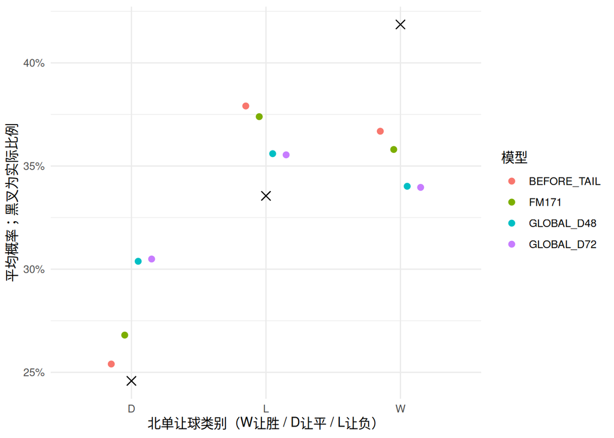

按零/非零让球及决策日描述；不在这些分组上择优调参

| model | group | n | hits1 | hits2 | brier | logloss | dimension |
| --- | --- | --- | --- | --- | --- | --- | --- |
| BEFORE_TAIL | NONZERO | 113 | 43 | 83 | 0.68988 | 1.13059 | handicap |
| BEFORE_TAIL | ZERO | 188 | 76 | 130 | 0.65355 | 1.07901 | handicap |
| FM171 | NONZERO | 113 | 43 | 78 | 0.69608 | 1.14257 | handicap |
| FM171 | ZERO | 188 | 77 | 131 | 0.65476 | 1.08113 | handicap |
| GLOBAL_D48 | NONZERO | 113 | 43 | 74 | 0.69156 | 1.14102 | handicap |
| GLOBAL_D48 | ZERO | 188 | 75 | 128 | 0.66225 | 1.09340 | handicap |
| GLOBAL_D72 | NONZERO | 113 | 43 | 73 | 0.69182 | 1.14186 | handicap |
| GLOBAL_D72 | ZERO | 188 | 72 | 129 | 0.66318 | 1.09472 | handicap |
| BEFORE_TAIL | 2026-10-08 | 55 | 27 | 39 | 0.64619 | 1.07542 | decision_date |
| BEFORE_TAIL | 2026-10-09 | 123 | 52 | 94 | 0.65510 | 1.07707 | decision_date |
| BEFORE_TAIL | 2026-10-10 | 95 | 30 | 62 | 0.68748 | 1.12805 | decision_date |
| BEFORE_TAIL | 2026-10-11 | 27 | 9 | 17 | 0.69700 | 1.14278 | decision_date |
| BEFORE_TAIL | 2026-10-12 | 1 | 1 | 1 | 0.57580 | 0.96335 | decision_date |
| FM171 | 2026-10-08 | 55 | 27 | 35 | 0.64985 | 1.08553 | decision_date |
| FM171 | 2026-10-09 | 123 | 54 | 96 | 0.65897 | 1.08334 | decision_date |
| FM171 | 2026-10-10 | 95 | 30 | 61 | 0.68941 | 1.13107 | decision_date |
| FM171 | 2026-10-11 | 27 | 8 | 16 | 0.70002 | 1.14844 | decision_date |
| FM171 | 2026-10-12 | 1 | 1 | 1 | 0.56258 | 0.94729 | decision_date |
| GLOBAL_D48 | 2026-10-08 | 55 | 29 | 34 | 0.66106 | 1.10595 | decision_date |
| GLOBAL_D48 | 2026-10-09 | 123 | 51 | 87 | 0.66457 | 1.09471 | decision_date |
| GLOBAL_D48 | 2026-10-10 | 95 | 28 | 64 | 0.68389 | 1.12405 | decision_date |
| GLOBAL_D48 | 2026-10-11 | 27 | 9 | 16 | 0.70290 | 1.15669 | decision_date |
| GLOBAL_D48 | 2026-10-12 | 1 | 1 | 1 | 0.60169 | 1.00278 | decision_date |
| GLOBAL_D72 | 2026-10-08 | 55 | 26 | 34 | 0.66451 | 1.11170 | decision_date |
| GLOBAL_D72 | 2026-10-09 | 123 | 51 | 86 | 0.66471 | 1.09496 | decision_date |
| GLOBAL_D72 | 2026-10-10 | 95 | 28 | 65 | 0.68382 | 1.12396 | decision_date |
| GLOBAL_D72 | 2026-10-11 | 27 | 9 | 16 | 0.70300 | 1.15683 | decision_date |
| GLOBAL_D72 | 2026-10-12 | 1 | 1 | 1 | 0.60169 | 1.00278 | decision_date |
| BEFORE_TAIL | market | 1 | 1 | 1 | 0.39301 | 0.71668 | routing |
| BEFORE_TAIL | native | 300 | 118 | 212 | 0.66810 | 1.09965 | routing |
| FM171 | market | 1 | 1 | 1 | 0.40058 | 0.72564 | routing |
| FM171 | native | 300 | 119 | 208 | 0.67117 | 1.10546 | routing |
| GLOBAL_D48 | market | 1 | 1 | 1 | 0.44440 | 0.77935 | routing |
| GLOBAL_D48 | native | 300 | 117 | 201 | 0.67402 | 1.11239 | routing |
| GLOBAL_D72 | market | 1 | 1 | 1 | 0.44440 | 0.77935 | routing |
| GLOBAL_D72 | native | 300 | 114 | 201 | 0.67470 | 1.11353 | routing |

前12个有效原生模型：0让球概率与同截止固定公司篮子欧赔去水均值；非联合市场λ

| fixture_id | native_W | native_D | native_L | companies | euro_W | euro_D | euro_L |
| --- | --- | --- | --- | --- | --- | --- | --- |
| 26103:1 | 0.3625 | 0.2867 | 0.3508 | 2 | 0.4148 | 0.2709 | 0.3143 |
| 26103:3 | 0.3406 | 0.3309 | 0.3286 | 2 | 0.5393 | 0.2692 | 0.1915 |
| 26103:4 | 0.4088 | 0.3025 | 0.2887 | 2 | 0.4128 | 0.3033 | 0.2839 |
| 26103:5 | 0.2819 | 0.2966 | 0.4215 | 1 | 0.3267 | 0.3042 | 0.3691 |
| 26103:6 | 0.3034 | 0.2895 | 0.4071 | 3 | 0.3011 | 0.2706 | 0.4282 |
| 26103:7 | 0.5018 | 0.2639 | 0.2343 | 3 | 0.5260 | 0.2439 | 0.2301 |
| 26103:8 | 0.3873 | 0.2988 | 0.3139 | 3 | 0.4353 | 0.2763 | 0.2884 |
| 26103:11 | 0.1575 | 0.2373 | 0.6052 | 2 | 0.1003 | 0.1799 | 0.7198 |
| 26103:13 | 0.5338 | 0.2177 | 0.2485 | 3 | 0.5495 | 0.2315 | 0.2190 |
| 26103:14 | 0.2970 | 0.2768 | 0.4263 | 2 | 0.4386 | 0.2651 | 0.2963 |
| 26103:15 | 0.4135 | 0.2814 | 0.3051 | 2 | 0.5401 | 0.2300 | 0.2299 |
| 26103:16 | 0.3877 | 0.2590 | 0.3533 | 1 | 0.4400 | 0.2667 | 0.2933 |

源数据版本固定为`source_issue_26103/20261014T225500527903Z`及`source_euro_issue_26103/20261016T011524878555Z`。通过`beidan::read_dataset()`/`dataset_query()`读取，单表读取后在R明确连接。metadata取接受事实来源Titan的原文，必须与NAS provenance哈希相同，parser绑定主客ID。场地中立标志是来源报告，不证明未标者确非中立。各重复赛果在共享准入后由现有opponent准备函数裁决冲突及去重；同赛事完整网络只用于支持/连通性门槛和已有raw输出，归一化λ不进入FM。

大部分场次缺少亚洲/大小球，伤停/阵容也不可用；可靠性全为uncertain并不表示全部球队实力相近。25场旧行情按固定48h报价年龄、欧赔至少3家/4家篮子、欧赔与亚洲最大残差均不超5个百分点进行审查；这沿用既有审查门槛，不在本期择优。历史对照的市场路线较多，本期市场稀疏，存在模型来源构成变化，不能把全局校准均值直接外推所有情景。输入比分口径是来源公布全场，90分钟及杯赛加时口径尚未独立认证。时钟争议场排除，不能自动择有利时钟。所有预测、源/实现哈希、权重账本及收据留在输出RDS，冷启动/支持不足不使用旧版顶替。407并非407个成功预测。

现有来源切换接口要求先有合格的原生网格。#391、#394虽有合格联合市场，却因原生同赛事支持不足留空；#405实际切换。这是当前实现的覆盖局限，不表示前两场市场不支持，也不通过伪造原生网格绕过接口。若将来支持“原生完全不可估但联合市场充分”的直接市场路线，应单独更新接口及验证版本，本轮不静默扩大FM范围。

逐场排除明细

| slot | home | away | league | reason |
| --- | --- | --- | --- | --- |
| 2 | 水原FC | 华城FC | 韩K2联 | Sparse target competition/venue support |
| 9 | 胡内多阿拉 | 沃伦塔利 | 罗甲 | Unresolved roster/analysis/market kickoff disagreement |
| 10 | 塞伊奈约基 | 拉赫蒂 | 芬超 | Unresolved roster/analysis/market kickoff disagreement |
| 12 | KS莫摩斯 | 华沙普洛克 | 波兰超 | Sparse target competition/venue support |
| 18 | 海登海姆 | 凯泽斯劳滕 | 德乙 | Sparse target competition/venue support |
| 20 | 阿姆斯特顿 | BW林茨 | 奥乙 | Sparse target competition/venue support |
| 25 | 佩纳菲尔 | AVS俱乐部 | 葡甲 | Sparse target competition/venue support |
| 26 | AB格莱萨克瑟 | 奥胡斯费马 | 丹麦甲 | Sparse target competition/venue support |
| 36 | 索肖 | 布洛涅 | 法乙 | Sparse target competition/venue support |
| 44 | 赫拉克勒斯 | 瓦尔韦克 | 荷乙 | Sparse target competition/venue support |
| 48 | 登德 | 布鲁日B队 | 比乙 | Sparse target competition/venue support |
| 58 | 波希米亚人 | 沃特福德联队 | 爱足杯 | Sparse target competition/venue support |
| 65 | 西汉姆联 | 女王公园巡游者 | 英冠 | Sparse target competition/venue support |
| 89 | 达姆施塔特 | 科特布斯 | 德乙 | Sparse target competition/venue support |
| 91 | 奥斯纳布鲁克 | 德累斯顿 | 德乙 | Sparse target competition/venue support |
| 98 | 诺茨郡 | 牛津联队 | 英甲 | Sparse target competition/venue support |
| 105 | 南特 | 兰斯 | 法乙 | Sparse target competition/venue support |
| 108 | 贝内文托 | 切塞纳 | 意乙 | Sparse target competition/venue support |
| 110 | 南蒂罗尔 | 阿斯科利 | 意乙 | Sparse target competition/venue support |
| 114 | 赫拉德茨克拉洛韦 | 阿蒂斯布尔诺 | 捷甲 | Sparse target competition/venue support |
| 117 | 阿马兰迪 | 朴迪莫伦斯 | 葡甲 | Sparse target competition/venue support |
| 122 | 柏林联合 | 埃弗斯堡 | 德甲 | Sparse target competition/venue support |
| 123 | 帕德博恩 | 斯图加特 | 德甲 | Sparse target competition/venue support |
| 127 | 维也纳迅速青年队 | 瓦克蒂罗尔 | 奥乙 | Sparse target competition/venue support |
| 132 | 博尔顿 | 斯托克城 | 英冠 | Sparse target competition/venue support |
| 134 | 米德尔斯堡 | 狼队 | 英冠 | Sparse target competition/venue support |
| 136 | 谢菲尔德联队 | 林肯城 | 英冠 | Sparse target competition/venue support |
| 139 | 剑桥联 | 布莱克浦 | 英甲 | Unresolved roster/analysis/market kickoff disagreement |
| 141 | 哈德斯菲尔德 | 谢周三 | 英甲 | Sparse target competition/venue support |
| 142 | 莱斯特城 | 彼得堡联 | 英甲 | Sparse target competition/venue support |

[output cut: 74 more lines]

时间冲突原值及差值（分钟）；不按结果择钟或默认为零

| fixture_id | analysis_utc | roster_utc | market_titan | market_nowscore | roster_delta_minutes | titan_delta_minutes | nowscore_delta_minutes |
| --- | --- | --- | --- | --- | --- | --- | --- |
| 26103:9 | 2026-10-09 15:00:00 | NA | 2026-10-09 15:00:00 | 2026-10-09 15:00:00 | NA | 0 | 0 |
| 26103:10 | 2026-10-09 15:00:00 | NA | 2026-10-09 15:00:00 | 2026-10-09 15:00:00 | NA | 0 | 0 |
| 26103:139 | 2026-10-10 14:10:00 | 2026-10-10 14:00:00 | 2026-10-10 14:10:00 | 2026-10-10 14:10:00 | -10 | 0 | 0 |
| 26103:182 | 2026-10-10 15:00:00 | NA | 2026-10-10 15:00:00 | 2026-10-10 15:00:00 | NA | 0 | 0 |
| 26103:183 | 2026-10-10 15:00:00 | NA | 2026-10-10 15:00:00 | 2026-10-10 15:00:00 | NA | 0 | 0 |
| 26103:184 | 2026-10-10 15:00:00 | NA | 2026-10-10 15:00:00 | 2026-10-10 15:00:00 | NA | 0 | 0 |
| 26103:185 | 2026-10-10 15:00:00 | NA | 2026-10-10 15:00:00 | 2026-10-10 15:00:00 | NA | 0 | 0 |
| 26103:186 | 2026-10-10 15:15:00 | NA | 2026-10-10 15:15:00 | 2026-10-10 15:15:00 | NA | 0 | 0 |
| 26103:187 | 2026-10-10 15:15:00 | NA | 2026-10-10 15:15:00 | 2026-10-10 15:15:00 | NA | 0 | 0 |
| 26103:188 | 2026-10-10 15:30:00 | NA | 2026-10-10 15:30:00 | 2026-10-10 15:30:00 | NA | 0 | 0 |
| 26103:189 | 2026-10-10 15:30:00 | NA | 2026-10-10 15:30:00 | 2026-10-10 15:30:00 | NA | 0 | 0 |
| 26103:207 | 2026-10-10 17:10:00 | 2026-10-10 17:00:00 | 2026-10-10 17:10:00 | 2026-10-10 17:10:00 | -10 | 0 | 0 |
| 26103:217 | 2026-10-10 18:30:00 | 2026-10-10 18:30:00 | 2026-10-10 18:40:00 | 2026-10-10 18:40:00 | 0 | 10 | 10 |
| 26103:238 | 2026-10-10 23:30:00 | 2026-10-10 23:40:00 | 2026-10-10 23:30:00 | 2026-10-10 23:30:00 | 10 | 0 | 0 |
| 26103:239 | 2026-10-10 23:40:00 | 2026-10-10 23:40:00 | 2026-10-10 23:30:00 | 2026-10-10 23:30:00 | 0 | -10 | -10 |
| 26103:240 | 2026-10-10 23:40:00 | 2026-10-10 23:40:00 | 2026-10-10 23:30:00 | 2026-10-10 23:30:00 | 0 | -10 | -10 |
| 26103:241 | 2026-10-10 23:40:00 | 2026-10-10 23:40:00 | 2026-10-10 23:30:00 | 2026-10-10 23:30:00 | 0 | -10 | -10 |
| 26103:242 | 2026-10-10 23:40:00 | 2026-10-10 23:40:00 | 2026-10-10 23:30:00 | 2026-10-10 23:30:00 | 0 | -10 | -10 |
| 26103:243 | 2026-10-10 23:30:00 | 2026-10-10 23:40:00 | 2026-10-10 23:30:00 | 2026-10-10 23:30:00 | 10 | 0 | 0 |
| 26103:244 | 2026-10-10 23:40:00 | 2026-10-10 23:40:00 | 2026-10-10 23:30:00 | 2026-10-10 23:30:00 | 0 | -10 | -10 |
| 26103:247 | 2026-10-11 00:40:00 | 2026-10-11 00:40:00 | 2026-10-11 00:30:00 | 2026-10-11 00:30:00 | 0 | -10 | -10 |
| 26103:248 | 2026-10-11 00:40:00 | 2026-10-11 00:40:00 | 2026-10-11 00:30:00 | 2026-10-11 00:30:00 | 0 | -10 | -10 |
| 26103:249 | 2026-10-11 00:40:00 | 2026-10-11 00:40:00 | 2026-10-11 00:30:00 | 2026-10-11 00:30:00 | 0 | -10 | -10 |
| 26103:251 | 2026-10-11 01:30:00 | 2026-10-11 01:40:00 | 2026-10-11 01:30:00 | 2026-10-11 01:30:00 | 10 | 0 | 0 |
| 26103:314 | 2026-10-11 15:00:00 | NA | 2026-10-11 15:00:00 | 2026-10-11 15:00:00 | NA | 0 | 0 |
| 26103:315 | 2026-10-11 15:00:00 | NA | 2026-10-11 15:00:00 | 2026-10-11 15:00:00 | NA | 0 | 0 |
| 26103:316 | 2026-10-11 15:00:00 | NA | 2026-10-11 15:00:00 | 2026-10-11 15:00:00 | NA | 0 | 0 |
| 26103:317 | 2026-10-11 15:00:00 | NA | 2026-10-11 15:00:00 | 2026-10-11 15:00:00 | NA | 0 | 0 |
| 26103:318 | 2026-10-11 15:00:00 | NA | 2026-10-11 15:00:00 | 2026-10-11 15:00:00 | NA | 0 | 0 |
| 26103:319 | 2026-10-11 15:00:00 | NA | 2026-10-11 15:00:00 | 2026-10-11 15:00:00 | NA | 0 | 0 |
| 26103:320 | 2026-10-11 15:00:00 | NA | 2026-10-11 15:00:00 | 2026-10-11 15:00:00 | NA | 0 | 0 |
| 26103:321 | 2026-10-11 15:00:00 | NA | 2026-10-11 15:00:00 | 2026-10-11 15:00:00 | NA | 0 | 0 |
| 26103:322 | 2026-10-11 15:00:00 | NA | 2026-10-11 15:00:00 | 2026-10-11 15:00:00 | NA | 0 | 0 |
| 26103:323 | 2026-10-11 15:00:00 | NA | 2026-10-11 15:00:00 | 2026-10-11 15:00:00 | NA | 0 | 0 |
| 26103:324 | 2026-10-11 15:00:00 | NA | 2026-10-11 15:00:00 | 2026-10-11 15:00:00 | NA | 0 | 0 |
| 26103:325 | 2026-10-11 15:00:00 | NA | 2026-10-11 15:00:00 | 2026-10-11 15:00:00 | NA | 0 | 0 |
| 26103:326 | 2026-10-11 15:00:00 | NA | 2026-10-11 15:00:00 | 2026-10-11 15:00:00 | NA | 0 | 0 |
| 26103:327 | 2026-10-11 15:15:00 | NA | 2026-10-11 15:15:00 | 2026-10-11 15:15:00 | NA | 0 | 0 |
| 26103:328 | 2026-10-11 15:15:00 | NA | 2026-10-11 15:15:00 | 2026-10-11 15:15:00 | NA | 0 | 0 |
| 26103:329 | 2026-10-11 15:30:00 | NA | 2026-10-11 15:30:00 | 2026-10-11 15:30:00 | NA | 0 | 0 |
| 26103:330 | 2026-10-11 15:30:00 | NA | 2026-10-11 15:30:00 | 2026-10-11 15:30:00 | NA | 0 | 0 |
| 26103:331 | 2026-10-11 15:30:00 | NA | 2026-10-11 15:30:00 | 2026-10-11 15:30:00 | NA | 0 | 0 |
| 26103:332 | 2026-10-11 15:30:00 | NA | 2026-10-11 15:30:00 | 2026-10-11 15:30:00 | NA | 0 | 0 |
| 26103:371 | 2026-10-11 23:00:00 | 2026-10-11 23:10:00 | 2026-10-11 23:00:00 | 2026-10-11 23:00:00 | 10 | 0 | 0 |
| 26103:378 | 2026-10-12 15:00:00 | NA | 2026-10-12 15:00:00 | 2026-10-12 15:00:00 | NA | 0 | 0 |
| 26103:379 | 2026-10-12 15:00:00 | NA | 2026-10-12 15:00:00 | 2026-10-12 15:00:00 | NA | 0 | 0 |
| 26103:380 | 2026-10-12 15:00:00 | NA | 2026-10-12 15:00:00 | 2026-10-12 15:00:00 | NA | 0 | 0 |

全局主时钟校正改变Top2命中的全部场次；事后归因，不用于再调参

| fixture_id | home | away | league | actual_outcome | top2_FM171 | top2_GLOBAL_D48 | brier_FM171 | brier_GLOBAL_D48 |
| --- | --- | --- | --- | --- | --- | --- | --- | --- |
| 26103:102 | 埃斯比约 | 奥尔堡 | 丹麦甲 | D | FALSE | TRUE | 0.73559 | 0.65598 |
| 26103:107 | 热那亚 | 佛罗伦萨 | 意甲 | W | TRUE | FALSE | 0.73947 | 0.76783 |
| 26103:112 | 比尔森胜利 | 博雷斯拉夫 | 捷甲 | W | TRUE | FALSE | 0.88547 | 0.89441 |
| 26103:115 | 索尔纳 | 布洛马波卡纳 | 瑞典超 | L | TRUE | FALSE | 0.73694 | 0.76135 |
| 26103:116 | 哥德堡盖斯 | 天狼星 | 瑞典超 | L | TRUE | FALSE | 0.72413 | 0.75356 |
| 26103:128 | 阿斯顿维拉 | 布伦特福德 | 英超 | D | FALSE | TRUE | 0.79772 | 0.71784 |
| 26103:146 | 斯托克港 | 巴恩斯利 | 英甲 | W | TRUE | FALSE | 0.94070 | 0.94696 |
| 26103:148 | 布里斯托流浪 | 巴尼特 | 英乙 | L | TRUE | FALSE | 0.75141 | 0.77681 |
| 26103:149 | 切尔滕汉姆 | 索尔福德市 | 英乙 | L | TRUE | FALSE | 0.68144 | 0.71242 |
| 26103:151 | 弗利特伍德 | 沃尔索尔 | 英乙 | D | FALSE | TRUE | 0.72603 | 0.64644 |
| 26103:16 | 卡亚尼卡帕 | MP米克力 | 芬甲 | D | FALSE | TRUE | 0.78581 | 0.70615 |
| 26103:160 | 哈茨 | 圣米伦 | 苏超 | W | TRUE | FALSE | 0.74997 | 0.77185 |
| 26103:167 | 托尔 | 韦斯特曼纳埃亚尔 | 冰岛超 | W | TRUE | FALSE | 0.68878 | 0.71727 |
| 26103:173 | 拉茨流浪者 | 女王公园 | 苏冠 | W | TRUE | FALSE | 0.86180 | 0.87456 |
| 26103:193 | 卢加诺 | 卢塞恩 | 瑞士超 | W | TRUE | FALSE | 0.84357 | 0.85469 |
| 26103:196 | 玛丽港 | 埃尔维斯 | 芬超 | D | FALSE | TRUE | 0.79165 | 0.71411 |
| 26103:197 | 拉路维尔 | 布鲁日 | 比甲 | L | TRUE | FALSE | 0.89873 | 0.90726 |
| 26103:203 | AEK雅典 | OFI克里特 | 希腊超 | W | TRUE | FALSE | 0.89168 | 0.90071 |
| 26103:204 | 霍布罗 | 科灵 | 丹麦甲 | D | FALSE | TRUE | 0.75630 | 0.67960 |
| 26103:216 | 布加勒斯特星队 | 加拉茨钢铁 | 罗甲 | D | FALSE | TRUE | 0.92883 | 0.85656 |
| 26103:22 | 布兰 | 维京 | 挪超 | L | TRUE | FALSE | 0.67209 | 0.70426 |
| 26103:236 | 华雷斯 | 蒂华纳 | 墨西联 | D | FALSE | TRUE | 0.75630 | 0.68361 |
| 26103:252 | 洛杉矶FC | 温哥华白浪 | 美职业 | D | FALSE | TRUE | 0.80395 | 0.72432 |
| 26103:255 | 千叶市原 | 长崎成功丸 | 日职联 | D | FALSE | TRUE | 0.75653 | 0.67735 |
| 26103:257 | 富山胜利 | 宫崎棒牛鸟 | 日职乙 | D | FALSE | TRUE | 0.74811 | 0.66889 |
| 26103:260 | 东京绿茵 | 广岛三箭 | 日职联 | L | TRUE | FALSE | 0.75021 | 0.77195 |
| 26103:267 | 科莫 | 罗马 | 意甲 | D | FALSE | TRUE | 0.77899 | 0.69968 |
| 26103:269 | 马瑟韦尔 | 凯尔特人 | 苏超 | L | TRUE | FALSE | 0.82768 | 0.84039 |
| 26103:271 | 奥雷布洛 | 卢恩斯基尔 | 瑞典甲 | D | FALSE | TRUE | 0.71560 | 0.63629 |
| 26103:272 | 圣保利 | 卡尔斯鲁厄 | 德乙 | W | TRUE | FALSE | 0.93465 | 0.94082 |
| 26103:273 | 柏林赫塔 | 菲尔特 | 德乙 | D | FALSE | TRUE | 0.91621 | 0.83815 |
| 26103:277 | 安道尔FC | 卡斯迪隆 | 西乙 | W | TRUE | FALSE | 0.72435 | 0.75414 |
| 26103:279 | 兰讷斯 | 维堡 | 丹麦超 | L | TRUE | FALSE | 0.69058 | 0.72232 |
| 26103:288 | 腓特烈斯塔 | 特罗姆瑟 | 挪超 | D | FALSE | TRUE | 0.80447 | 0.72526 |
| 26103:297 | 特普利斯 | 奥洛穆茨 | 捷甲 | D | FALSE | TRUE | 0.76167 | 0.68262 |
| 26103:305 | 布隆德比 | 利恩比 | 丹麦超 | W | TRUE | FALSE | 0.82667 | 0.83996 |
| 26103:306 | 艾斯登 | 亨克B队 | 比乙 | D | FALSE | TRUE | 0.98855 | 0.91171 |
| 26103:307 | 皇家社会 | 拉科鲁尼亚 | 西甲 | D | FALSE | TRUE | 0.96000 | 0.88213 |
| 26103:309 | 里奥阿维 | 葡萄牙国民 | 葡超 | W | TRUE | FALSE | 0.71858 | 0.75160 |
| 26103:310 | 圣加仑 | 洛桑 | 瑞士超 | D | FALSE | TRUE | 0.93311 | 0.85520 |
| 26103:313 | SBV精英 | 格罗宁根 | 荷甲 | L | TRUE | FALSE | 0.69187 | 0.72188 |
| 26103:32 | USL敦刻尔克 | 阿纳西 | 法乙 | L | TRUE | FALSE | 0.72387 | 0.75398 |
| 26103:339 | 韦斯特洛 | 安特卫普 | 比甲 | W | TRUE | FALSE | 0.69111 | 0.71911 |
| 26103:34 | 南锡 | 甘冈 | 法乙 | W | TRUE | FALSE | 0.70645 | 0.73601 |
| 26103:340 | 本菲卡 | 吉马良斯 | 葡超 | D | FALSE | TRUE | 0.94459 | 0.86685 |
| 26103:343 | 根特B队 | 瑟兰联 | 比乙 | W | TRUE | FALSE | 0.72113 | 0.75076 |
| 26103:364 | 弗拉门戈 | 弗鲁米嫩塞 | 巴西甲 | D | FALSE | TRUE | 0.89567 | 0.81714 |
| 26103:369 | 巴伊亚 | 米拉索 | 巴西甲 | D | FALSE | TRUE | 0.88302 | 0.80386 |
| 26103:37 | 埃因霍温 | 海伦芬 | 荷甲 | D | FALSE | TRUE | 1.05479 | 0.98184 |
| 26103:372 | 圣路易斯竞技 | 桑托斯拉古纳 | 墨西联 | L | TRUE | FALSE | 0.81645 | 0.83652 |
| 26103:386 | 奥胡斯 | 桑德捷斯基 | 丹麦超 | W | TRUE | FALSE | 0.81659 | 0.83048 |
| 26103:395 | 莱万特 | 塞维利亚 | 西甲 | D | FALSE | TRUE | 0.78956 | 0.71064 |
| 26103:398 | 科里蒂巴 | 博塔弗戈 | 巴西甲 | D | FALSE | TRUE | 0.76447 | 0.68516 |
| 26103:404 | 诺瓦里桑蒂诺 | 庞特普雷塔 | 巴西乙 | W | TRUE | FALSE | 0.85330 | 0.86628 |
| 26103:46 | 多德勒支 | 埃门 | 荷乙 | L | TRUE | FALSE | 0.77311 | 0.79154 |
| 26103:54 | 琴斯托霍瓦 | GKS卡托威斯 | 波兰超 | L | TRUE | FALSE | 0.75168 | 0.77884 |
| 26103:64 | 马拉加 | 西班牙人 | 西甲 | D | FALSE | TRUE | 0.71315 | 0.63443 |
| 26103:68 | 科尔多瓦学院 | 博卡青年 | 阿甲 | D | FALSE | TRUE | 0.71621 | 0.63733 |
| 26103:74 | RB大宫松鼠 | 八户云罗里 | 日职乙 | W | TRUE | FALSE | 0.88690 | 0.89652 |
| 26103:78 | 全南天龙 | 龙仁FC | 韩K2联 | W | TRUE | FALSE | 0.66906 | 0.70200 |
| 26103:83 | 金泉尚武 | FC安养 | 韩K联 | L | TRUE | FALSE | 0.67835 | 0.71328 |
| 26103:88 | 通德拉 | 杜连斯 | 葡甲 | W | TRUE | FALSE | 0.67810 | 0.71580 |
| 26103:90 | 马格德堡 | 汉诺威96 | 德乙 | W | TRUE | FALSE | 0.76639 | 0.79178 |
| 26103:95 | 查尔顿 | 布里斯托城 | 英冠 | D | FALSE | TRUE | 0.71415 | 0.63469 |
| 26103:99 | 普利茅斯 | AFC温布尔登 | 英甲 | D | FALSE | TRUE | 0.88700 | 0.80892 |

复现顺序：加载`config/source-extraction.env`和已声明R_LIBS，使用`.venv/bin/python`及`/opt/R/4.6.1/bin/Rscript`。先运行`r/fm171_26103_intake.R ROOT`，`src/fm171_26103_metadata.py ROOT`（再次加replay），`src/fm171_26103_sp_intake.py ROOT`及`src/fm171_26103_market_intake.py ROOT`；运行`r/fm171_26103_market_freeze.R ROOT`及`replay`，再运行原生冻结客户端的`ROOT shard i 4`（i=1…4）。分片是固定取模的计算分工，各分片仍使用完整407场目标名单与全部已知未来名单，不是学习分区。默认`ROOT`核对缓存身份后组装全期；`ROOT replay-shard i 4`逐场全新计算、忽略缓存并与全期快照精确比较，再由`r/fm171_26103_native_replay_accept.R ROOT`验证四份互斥清单合计407。也可使用未分片的`ROOT replay`整批精确重算。随后`r/fm171_26103_sp_freeze.R ROOT`及`replay`、`r/fm171_26103_calibrate.R ROOT`及`replay`，最后`r/fm171_26103_evaluate.R ROOT`。`run-build.py`保存上述实际argv、退出码及明确环境。不可变预测存在时只接受完全一致对象，不覆盖不同内容。安装依赖属于环境设置，渲染不安装、不下载、不写NAS。

本轮新增的是有界研究客户端，没有修改包内函数。复用函数、客户端与验证的对应关系如下；所有历史准入、分区、权重、ESS、缓存键及模型收据仍由共享`temporal_learning`提供，没有复制时间学习工具。

| 环节与复用函数 | 本轮验证 |
| --- | --- |
| NAS读取、赛事metadata与原文解析客户端 | 六份输入独立读回字节一致；407包metadata重放；传递解析器及原文哈希；物理Parquet哈希 |
| `prepare_opponent_goals`、`FitOpponentGoals`的`same_support_raw` | 全407场重新计算；测试逐场独立重算主客λ、12场门槛与完整未来ID排除 |
| `SelectFmProbabilitySource` | 测试逐场按审查条件核对来源及所选网格；完整来源收据重放 |
| `BuildFmTailJudgement`、`adjust_score_margin_distribution` | 测试逐格核心/外围权重、归一化、完整两侧质量及比分条件比例 |
| 共享截止/权重与GLOBAL固定拟合表达式 | 测试严格标签/源截止、实际拟合表达式的目标/未来标签变动不变性、不同输入缓存隔离 |
| 原生缓存与评分标签绑定 | 实际缓存断言的赛程哈希变动拒绝；实际评分断言的让球变动拒绝 |
| `parse_prematch_sp`及SP准入/折算客户端 | 三份原始观察收据离线解析；ID/让球/时间一致；196/20覆盖、严格截止及倒数归一化测试 |
| `DcAccuracyDiagnostic`与评分客户端 | 独立评分CSV字节一致；逐模型命中数、三类及二元Brier、log loss独立核算 |
| QMD交付入口 | 新进程无缓存渲染、数据/源码哈希门禁、表格图形与执行错误检查；预览标量遮蔽问题由修复后的实际渲染验证 |

实际自动测试、完整回归、重放、codex review及源码身份验收

[output not shown]